# Fall 2020 STAT 240 Final Exam

#### Due Saturday, December 12, 2020 at 11:59 PM CT (local time in Madison, WI)

#### NAME: REPLACE THIS TEXT WITH YOUR FULL NAME

### Preliminaries

- You will have 24 hours to complete the exam, and your solutions should be uploaded to Canvas by 11:59 PM CT (the time zone in Madison, WI).
- You are not allowed to communicate with anyone using any means (email, phone, text, social media, online discussion platforms, etc.) except the instructors of this course. You are allowed to use materials from the course and the internet.
- If you have a question during the exam, post your question as a *private* post on Piazza. To do this, select the “Individual Student(s) / Instructor(s)” option next to “Post to:” when creating your post.
- It is recommended that you begin the exam as soon as possible and read over it to see if you have any questions. You can expect for questions to be addressed during normal working hours in Madison, WI (9 AM CT - 5 PM CT). Questions posted outside that window *may* still be addressed.

### Submission

Once you have completed the exam, knit the R Markdown document to create an HTML file. To submit this Exam, go to our Canvas site and select “Assignments” on the left panel, and upload both the edited Rmd and HTML files to the place designated for the final exam. *Be sure to review the HTML to verify all your answers appear as you expect.*

### Data

The following data files are needed to complete this exam. More information about the data sets are provided later in the exam.

Danish Family Data:  
*danish-children.csv*

Dollar General Data:  
*dollar_general_counts.csv*  
*georgia_population_by_county.csv*  
*georgia_fei_2020_actual.csv*

Bike Trip Data:  
*trip.csv*

# Problems

The exam has a total of 15 problems, some with several parts, totaling 57 points.

## Short Answer Questions

### Problem 1 (2 points)

In a hypothesis test about an unknown parameter, the test statistic…

**Select the best response**

1. measures the compatibility between the null and alternative hypotheses
2. is the value of the unknown parameter under the null hypothesis
3. measures the compatibility between the null hypothesis and data
4. is the value of the unknown parameter under the alternative hypothesis
5. None of the above

REPLACE THIS TEXT WITH YOUR RESPONSE

### Problem 2 (3 points)

A particle randomly moves along a line. That is, the particle starts at the origin (position 0) and moves either right or left in independent steps of length 0, 1, or 2 (where length 0 means the particle stays in its current location).

The distribution of the particle’s movement at step i is listed in the table below called `x_distribution`. $X_i$ is the random variable with the distribution below, and $x_i$ are the possible values $X_i$ can take. The probability of each $x_i$ is listed below under $P(X_i = x_i)$.

```r
x_distribution <- tibble(x_i = c(-2, -1, 0, 1),
                         `P(X_i=x_i)` = c(.5, .2, .1, .2))
x_distribution
```

```
## # A tibble: 4 x 2
##     x_i `P(X_i=x_i)`
##   <dbl>        <dbl>
## 1    -2          0.5
## 2    -1          0.2
## 3     0          0.1
## 4     1          0.2
```

The position of the particle after $k$ steps is the sum of these random movements
$$Y = X_1+X_2+...+X_k.$$
The probability distribution of $Y$ (with computed values rounded to the nearest 0.01) is

1. Exactly Normal with mean = $0$ and variance = $1.67/k$
2. Exactly Normal with mean = $−0.5$ and variance = $1.67/k$
3. Exactly Normal with mean = $−1$ and variance = $1.4/k$
4. Approximately Normal with mean = $0$ and variance = $1.3/k$
5. Approximately Normal with mean = $−0.5$ and variance = $1.4/k$
6. Approximately Normal with mean = $−1$ and variance = $1.67/k$
7. None of the above.

REPLACE THIS TEXT WITH YOUR RESPONSE

### Solution

Since the distribution of $X_1, . . . , X_k$ is not normal, the distribution of $Y$ will only be approximately normal by the Central Limit Theorem with the following mean and variance:

```r
## Solution

x <- c(-2, -1, 0, 1)
p <- c(.5, .2, .1, .2)

x_mean <- sum(x*p) # mean
x_mean
```

```
## [1] -1
```

```r
x_var <- sum((x-x_mean)^2*p) # var
x_var
```

```
## [1] 1.4
```

### Problem 3 (3 points)

The weight, X, of cherry tomatoes selected at random from a very large bin at the local supermarket follows a Normal distribution with mean 3 oz. and standard deviation 2 oz. Suppose we pick 8 cherry tomatoes from the bin at random (independently) and put them in our bag. What is the probability that exactly 5 of the 8 cherry tomatoes weigh less than 4 oz (rounded to the nearest 0.01)?

REPLACE THIS TEXT WITH YOUR RESPONSE

### Solution

Let Y be the number of cherry tomatoes of 8 that weigh less than 4 oz. Then $Y\sim \text{Binomial}(8,p)$ where $p=P(X<4)$.

```r
## Solution

p <- pnorm(4, 3, 2)
p
```

```
## [1] 0.6914625
```

```r
round(dbinom(5,8,p),2)
```

```
## [1] 0.26
```

### Problem 4 (3 points)

Suppose a confidence interval for the mean weight increase of pregnant women in their first 5 months of pregnancy is found to be 16 +/- 0.134 lbs based on a random sample of size n = 400. Assuming the population standard deviation is known to be 2 lbs, what confidence level was used to calculate this confidence interval (rounded to the nearest %)?

REPLACE THIS TEXT WITH YOUR RESPONSE

### Solution

```r
## Solution

mar <- .134
sig <- 2
n <- 400

z <- mar/2*sqrt(n)
z
```

```
## [1] 1.34
```

```r
tail_prob <- pnorm(-abs(z))

round((1-2*tail_prob)*100,0) ## confidence level
```

```
## [1] 82
```

## Danish Family Questions

Data for the next set of questions is in the file *danish-children.csv* which was collected from 1960 to 1994 from all Danish families with only single births. Each row is a summary of the number of children in a family in the data set with a given birth order, sex, and the sequence of the sexes of any previous children in the family. There are four columns in this data set.

- `order` - the birth order;
- `sex` - F or M depending on sex assigned at birth;
- `previous` - the sequence of sexes of previous children in the family;
- `n` - the count of the number of such children

### Problem 5 (3 points)

Define $p_1$ to be the probability that a third child is a girl among families who have a third child after first having two girls. Let $p_2$ be the probability that a third child is a girl among families who have a third child after first having two boys. Treat the observed children in this data set as a sample from a population of potential children that might have been born in these families. Determine the data below and estimate these two probabilities:

- $n_1$ is the number of families that have a third child after having two girls.
- $x_1$ is the number of girls from such families.
- $n_2$ is the number of families that have a third child after having two boys.
- $x_2$ is the number of girls from such families.

REPLACE THIS TEXT WITH YOUR RESPONSE

### Solution

```r
## Solution

dc = read_csv("../../data/danish-children.csv")

dc3 = dc %>%
  filter(order == 3 & (previous == "FF" | previous == "MM"))

prob1 = dc3 %>%
  group_by(previous) %>%
  summarize(
    x = n[sex == "F"],
    n = sum(n),
    phat = x/n)

prob1
```

```
## # A tibble: 2 x 4
##   previous     x     n  phat
##   <chr>    <dbl> <dbl> <dbl>
## 1 FF       18770 38184 0.492
## 2 MM       21808 45044 0.484
```

### Problem 6 (5 points)

**(a)** Find a 95% confidence interval for $p_1 - p_2$.  
**(b)** Interpret the meaning of this interval in context.

REPLACE THIS TEXT WITH YOUR RESPONSE

### Solution

**(a)**

```r
## Solution

ci = prob1 %>%
  mutate(se2 = phat*(1-phat)/n) %>%
  summarize(estimate = -diff(phat),
            se = sqrt(sum(se2))) %>%
  mutate(z = qnorm(0.975),
         me = z*se,
         a = estimate - me,
         b = estimate + me)

ci
```

```
## # A tibble: 1 x 6
##   estimate      se     z      me        a      b
##      <dbl>   <dbl> <dbl>   <dbl>    <dbl>  <dbl>
## 1  0.00742 0.00348  1.96 0.00681 0.000603 0.0142
```

A 95% confidence interval for $p_1 - p_2$ is $(0.0006, 0.0142)$.

**(b)** We are 95% confident that the probaiblity of having a girl is between 0.0006 and 0.0142 larger among families with two previous girls than among families with two previous boys in this population of Danish families.

### Problem 7 (8 points)

Test the null hypothesis that $p_1 = p_2$ versus the two-sided alternative.

**(a)** State hypotheses  
**(b)** Calculate a test statistic  
**(c)** Report a p-value  
**(d)** Interpret the result of the test in the context of the problem.

REPLACE THIS TEXT WITH YOUR RESPONSE

### Solution

**(a)**

$H_0: p_1 = p_2$  
$H_A: p_1 \neq p_2$

**(b)** and **(c)**

```r
## Solution

## Z-test
## pooled estimate of p
p_pooled = prob1 %>%
  summarize(x = sum(x),
            n = sum(n),
            p = x/n) %>%
  pull(p)

p_pooled
```

```
## [1] 0.4875523
```

```r
## z test statistic
hyp = prob1 %>%
  summarize(estimate = -diff(phat),
            se = sqrt(p_pooled*(1-p_pooled)*sum(1/n)),
            z = estimate/se,
            pvalue = 2*pnorm(-abs(z)))

hyp
```

```
## # A tibble: 1 x 4
##   estimate      se     z pvalue
##      <dbl>   <dbl> <dbl>  <dbl>
## 1  0.00742 0.00348  2.13 0.0329
```

The test statistic is $z = 2.13$.

The p-value is $p = 0.033$.

**(d)** There is evidence that the probability of having a girl is larger after having two previous girls than after having two previous boys ($p = 0.033$, z-test for proportions).

#### Alternative simulation based test

```r
## Solution
set.seed(20201208)
B = 100000
d = numeric(B)
for ( i in 1:B )
{
  p1 = rbinom(1, prob1$n[1], p_pooled) / prob1$n[1]
  p2 = rbinom(1, prob1$n[2], p_pooled) / prob1$n[2]
  d[i] = p1 - p2
}

pvalue = mean(abs(d) >= abs(hyp$estimate))
pvalue
```

```
## [1] 0.03358
```

## Dollar General Questions

Dollar General is a chain of budget stores that has grown rapidly across the country at a time when many other retailers are shrinking. Part of their formula of success is to sell inexpensive food which is often processed and unhealthy, often undercutting local stores which sell more expensive and healthy food options, sometimes driving these competitors out of business.

Researchers have developed the Food Environment Index (FEI) to measure the food environment in neighborhoods. The FEI combines a measure of proximity to healthy food among low income residents with a measure of food insecurity and takes values on a scale from 0 (worst) to 10 (best). Values in a county are averaged over values in smaller units within the county. In 2020, the median value for counties in the United States was 7.6 and most counties fell between about 6.9 and 8.2. For comparison, in Wisconsin, the mean across counties is 8.5 and most (plus or minus one standard deviation) are between 8.0 and 9.0 and the value in Dane county, in which Madison is situated, is 8.2.

One complaint about Dollar General stores is that when a new store opens in a small town, local grocers compete poorly and are put out of business, causing people to lose access to local healthy food options. The following questions examine an association between the FEI measured at the county level and the number of Dollar General stores per capita in counties in the state of Georgia.

Here are variable descriptions:

*dollar_general_counts.csv*

- `County` - the name of a county in Georgia
- `Dollar General` - the number of Dollar General stores in the county

*georgia_population_by_county.csv*

- `County` - the name of a county in Georgia
- `population` - the population of the county

*georgia_fei_2020_actual.csv*

- `FIPS` - a unique county identifier code used by federal agencies
- `State` - the state name (always Georgia for this data)
- `County` - the county name
- `Food Environment Index` - the average FEI value for the county

### Problem 8 (4 points)

Combine and transform data from the files *dollar_general_counts.csv*, *georgia_population_by_county.csv*, and *georgia_fei_2020_actual.csv* into a single data frame named `dg` with one row per county and with these columns:

- *county*: the name of the county
- *fei*: the Food Environment Index value
- *population*: the population of the county
- *stores*: the number of Dollar General stores
- *dg_per*: the number of Dollar General stores per 100,000 people.

Note that the state of Georgia has 159 counties. Any county that does not appear in the file *dollar_general_counts.csv* has no Dollar General Stores.

After creating the data frame, create and print a summary of the median values for each of the four quantitative variables as a tibble with a single row, discarding any missing observations in variables which have them, but using all non-missing data for each variable.

### Solution

```r
## Solution

dollar = read_csv("../../data/dollar_general_counts.csv") %>%
  rename(county = County,
         stores = `Dollar General`) %>%
  mutate(county = case_when(
    county == "Dekalb" ~ "DeKalb",
    county == "Mcduffie" ~ "McDuffie",
    county == "Mcintosh" ~ "McIntosh",
    TRUE ~ county))

pop = read_csv("../../data/georgia_population_by_county.csv") %>%
  rename(county = County)

fei = read_csv("../../data/georgia_fei_2020_actual.csv") %>%
  select(-FIPS, -State) %>%
  rename(county = County,
         fei = `Food Environment Index`)

dg = fei %>%
  left_join(pop) %>%
  left_join(dollar) %>%
  mutate(stores = case_when(
    is.na(stores) ~ 0,
    TRUE ~ stores)) %>%
  mutate(dg_per = 100000 * stores / population)

dg %>%
  select(-county) %>%
  summarize_all(median, na.rm = TRUE)
```

```
## # A tibble: 1 x 4
##     fei population stores dg_per
##   <dbl>      <dbl>  <dbl>  <dbl>
## 1  7.15      22646      4   17.5
```

### Problem 9 (4 points)

**(a)** Create a scatter plot with the number of Dollar General stores per 100,000 people on the x axis and FEI on the y axis. Indicate the county populations with the size of the points and set `alpha = 0.5` to make points partially transparent to lessen the visual impact of overplotting. Add a straight regression line to the plot.

**(b)** What is the slope of the regression line, rounded to three significant digits?

REPLACE THIS TEXT WITH YOUR RESPONSE

### Solution

**(a)**

[figure not shown]

```r
## Solution

ggplot(dg, aes(x = dg_per, y = fei, size = population)) +
  geom_point(alpha = 0.5) +
  geom_smooth(method = "lm", se = FALSE, show.legend = FALSE) +
  xlab("# Dollar General Stores per 100,000 population") +
  ylab("FEI") +
  ggtitle("FEI versus Dollar General store density",
          subtitle = "in Counties in Georgia")
```

```r
fit1 = lm(fei ~ dg_per, data = dg)
```

**(b)**

```r
## Slope
signif(coef(fit1),3)[2]
```

```
##  dg_per
## -0.0381
```

### Problem 10 (4 points)

The two counties with FEI values below three are outliers and potentially influential points for the fitted regression model.

**(a)** After removing these two points, replot the data and fit a regression line as before.

**(b)** Report the slope of this line, rounded to three significant digits.

### Solution

**(a)**

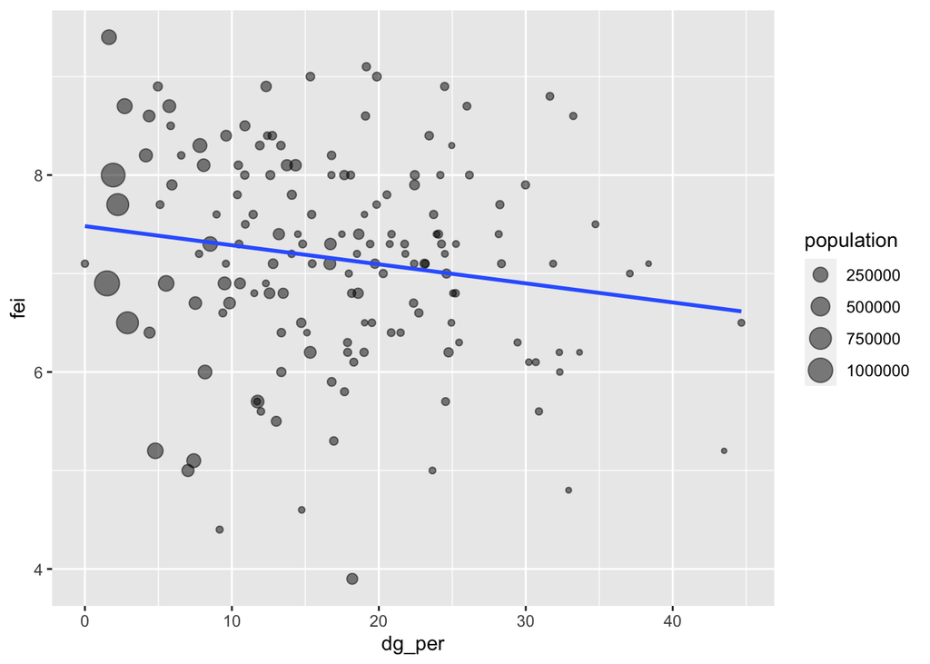

```r
## Solution

dg %>% filter(fei > 3) %>%
ggplot(aes(x = dg_per, y = fei, size = population)) +
  geom_point(alpha = 0.5) +
  geom_smooth(method = "lm", se = FALSE, show.legend = FALSE)
```

```r
fit2 = lm(fei ~ dg_per, data = filter(dg, fei > 3))

## Slope
signif(signif(coef(fit2),3)[2], 3)
```

```
##  dg_per
## -0.0194
```

### Problem 11 (3 points)

One county has missing data for the FEI.

**(a)** Identify this county and report the values of its non-missing data.

**(b)** Use each of the two regression models (using all data and with the two low FEI values removed) to predict the missing FEI value for this county, rounded to one decimal place.

REPLACE THIS TEXT WITH YOUR RESPONSE

### Solution

**(a)**

```r
## Solution

dg %>%
  filter(is.na(fei))
```

```
## # A tibble: 1 x 5
##   county   fei population stores dg_per
##   <chr>  <dbl>      <dbl>  <dbl>  <dbl>
## 1 White     NA      30798      5   16.2
```

- White county has a missing FEI value. It has five Dollar General Stores and a population of 30,798, for a density of 16.2 stores per 100,000.

**(b)**

```r
## Solution

round(predict(fit1,dg %>% filter(is.na(fei))), 1)
```

```
##   1
## 7.1
```

```r
round(predict(fit2,dg %>% filter(is.na(fei))), 1)
```

```
##   1
## 7.2
```

Or

```r
## Solution

round(sum(coef(fit1) * c(1,16.2)), 1)
```

```
## [1] 7.1
```

```r
round(sum(coef(fit2) * c(1,16.2)), 1)
```

```
## [1] 7.2
```

## Bike Trip Questions

The Bike Trip data are contained in the *trip.csv* file. The data were made available by the Bay Area Bike Share service and accessed through UC-Berkeley’s Data8 site, and include bike rentals from this program between September 1, 2014 and August 31, 2015. More information, including more extensive data, is available [here](https://www.sfmta.com/getting-around/bike/bike-share).

The data include the following variables:

- `Trip ID` - an identifer for each bike trip
- `Duration` - the length of the use of the bike in seconds
- `Start Date` - the date and time the bike trip started
- `Start Station` - the name of the station at which the bike trip started
- `Start Terminal` - the terminal number at the start of the bike trip
- `End Date` - the date and time the bike trip ended
- `End Station` - the name of the station at which the bike trip ended
- `End Terminal` - the terminal number at the end of the bike trip
- `Bike #` - the serial number identifying the bike
- `Subscriber Type` - indicated as “Subscriber” (i.e., a member of the bike sharing program) or “Customer” (a casual user of the bike sharing program)
- `Zip Code` - zip code of the user

### Problem 12 (4 points)

Define a data frame called `trip` by doing the following. Read in the *trip.csv* data set and rename the variables as listed below:

id = `Trip ID`,  
duration = `Duration`,  
start_date = `Start Date`,  
end_date = `End Date`,  
start_station = `Start Station`,  
end_station = `End Station`,  
start_terminal = `Start Terminal`,  
end_terminal = `End Terminal`,  
bike = `Bike #`,  
subscriber = `Subscriber Type`,  
zip = `Zip Code`

Additionally, add a variable `year` indicating the year of the start date of the bike trip, and add a variable `month` indicating the month of the start date of the bike trip.

**(a)** Use `print.data.frame(head(trip,6))` to print out the first 6 rows and all the columns of your `trip` data frame.

**(b)** Create a summary table that displays the minimum and maximum trip duration for each month. There should be 3 columns and 12 rows in this table. Print out this table.

REPLACE THIS TEXT WITH YOUR RESPONSE

### Solution

```r
## Solution

# **(a)**

trip <- read_csv("../../data/trip.csv") %>%
  rename(id = `Trip ID`,
         duration = Duration,
         start_date = `Start Date`,
         end_date = `End Date`,
         start_station = `Start Station`,
         end_station = `End Station`,
         start_terminal = `Start Terminal`,
         end_terminal = `End Terminal`,
         bike = `Bike #`,
         subscriber = `Subscriber Type`,
         zip = `Zip Code`)


trip <- trip %>%
  mutate(start_date = mdy_hm(start_date),
         year = year(start_date),
         month = month(start_date))

print.data.frame(head(trip,6))
```

```
##       id duration          start_date
## 1 913460      765 2015-08-31 23:26:00
## 2 913459     1036 2015-08-31 23:11:00
## 3 913455      307 2015-08-31 23:13:00
## 4 913454      409 2015-08-31 23:10:00
## 5 913453      789 2015-08-31 23:09:00
## 6 913452      293 2015-08-31 23:07:00
##                                   start_station start_terminal        end_date
## 1          Harry Bridges Plaza (Ferry Building)             50 8/31/2015 23:39
## 2                   San Antonio Shopping Center             31 8/31/2015 23:28
## 3                                Post at Kearny             47 8/31/2015 23:18
## 4                            San Jose City Hall             10 8/31/2015 23:17
## 5                         Embarcadero at Folsom             51 8/31/2015 23:22
## 6 Yerba Buena Center of the Arts (3rd @ Howard)             68 8/31/2015 23:12
##                                end_station end_terminal bike subscriber   zip
## 1 San Francisco Caltrain (Townsend at 4th)           70  288 Subscriber  2139
## 2                  Mountain View City Hall           27   35 Subscriber 95032
## 3                        2nd at South Park           64  468 Subscriber 94107
## 4                      San Salvador at 1st            8   68 Subscriber 95113
## 5                   Embarcadero at Sansome           60  487   Customer  9069
## 6 San Francisco Caltrain (Townsend at 4th)           70  538 Subscriber 94118
##   year month
## 1 2015     8
## 2 2015     8
## 3 2015     8
## 4 2015     8
## 5 2015     8
## 6 2015     8
```

```r
# **(b)**
trip %>%
  group_by(month) %>%
  summarize(min = min(duration),
            max = max(duration)) %>%
  print.data.frame()
```

```
##    month min      max
## 1      1  60   405271
## 2      2  60   655939
## 3      3  61   350903
## 4      4  60   611240
## 5      5  60  1852590
## 6      6  60  2137000
## 7      7  60  1133540
## 8      8  60   346545
## 9      9  60   489435
## 10    10  60   720454
## 11    11  60   305382
## 12    12  60 17270400
```

### Problem 13 (3 points)

Using your `trip` data frame, how many of the bike trips started at a Caltrain station? You can assume that all the Caltrain stations have “Caltrain” in the name of the station.

### Solution

```r
## Solution

## How many trips start at a Caltrain station
trip %>%
  group_by(start_station) %>%
  summarize(count = n()) %>%
  filter(str_detect(start_station, "Caltrain")) %>%
  summarize(sum = sum(count))
```

```
## # A tibble: 1 x 1
##     sum
##   <int>
## 1 60079
```

### Problem 14 (4 points)

Using your `trip` data frame, create a new data frame called `trip2` that has the start stations listed in the first column, the end stations listed across the rest of the columns, and the content of the table indicating the number of bike trips between each start and end station. For example, the table cell at row i and column j of the table should indicate how many bike trips took place between start station i and end station j. If there were no trips between two stations, the value of the table should be `0`.

Sort the rows in alphabetical order by start station. Note that start station names that begin with numbers can appear before start station names that begin with the letter “A.”

**(a)** Print out the first 10 rows of the table and at least 3 columns.

**(b)** How many start and end stations did not have any trips taken? That is, how many 0’s are in the `trip2` table?

REPLACE THIS TEXT WITH YOUR RESPONSE

### Solution

```r
## Solution

# **(a)**
trip2 <- trip %>%
  mutate(count = 1) %>%
  pivot_wider(id_cols=start_station, names_from=end_station, values_fill=0, values_from = count, values_fn = sum)

trip2 %>%
  arrange(start_station) %>%
  select(1:3) %>%
  slice(1:10) %>%
  print.data.frame()
```

```
##                       start_station San Francisco Caltrain (Townsend at 4th)
## 1                     2nd at Folsom                                     1153
## 2                 2nd at South Park                                     1025
## 3                   2nd at Townsend                                      845
## 4                     5th at Howard                                     1062
## 5                  Adobe on Almaden                                        0
## 6          Arena Green / SAP Center                                        0
## 7                   Beale at Market                                     1215
## 8         Broadway St at Battery St                                     1088
## 9   California Ave Caltrain Station                                        0
## 10 Castro Street and El Camino Real                                        0
##    Mountain View City Hall
## 1                        0
## 2                        0
## 3                        0
## 4                        0
## 5                        0
## 6                        0
## 7                        0
## 8                        0
## 9                        2
## 10                      49
```

```r
# **(b)**

## one option
trip2 %>%
  select(-start_station) %>%
  summarize_all(function(x) sum(x==0)) %>%
  mutate(zeros = pmap_dbl(select(.,everything()),sum)) %>%
  select(zeros)
```

```
## # A tibble: 1 x 1
##   zeros
##   <dbl>
## 1  3208
```

```r
## another option
trip2 %>%
  select(-start_station) %>%
  summarize_all(function(x) sum(x==0)) %>%
  mutate(zeros = sum(c_across())) %>%
  select(zeros)
```

```
## # A tibble: 1 x 1
##   zeros
##   <int>
## 1  3208
```

### Problem 15 (4 points)

Make a plot that displays the average duration for bike trips in each of the four seasons, where the seasons are specified as

- Spring = March, April, May
- Summer = June, July, August
- Fall = September, October, November
- Winter = December, January, February

Use a thin blue vertical line segment to visualize a 95% confidence interval for the mean for each season, a slightly thicker black segment to visualize the interval one standard error above and below the point estimate (i.e., the sample mean) for each season, and a point at the point estimate for each season. Label axes appropriately and add an informative title to the plot.

### Solution

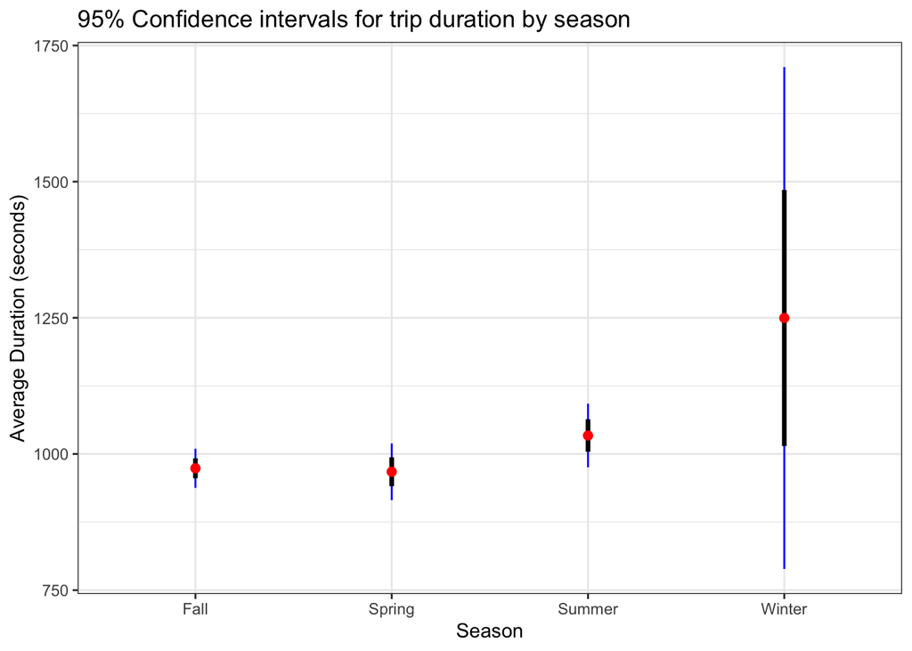

```r
## Solution
trip <- trip %>%
  mutate(season = case_when(
    month %in% c(3,4,5) ~ "Spring",
    month %in% c(6,7,8) ~ "Summer",
    month %in% c(9,10,11) ~ "Fall",
    month %in% c(12,1,2) ~ "Winter"
  ))

seasons <- trip %>%
  group_by(season) %>%
  summarize(mean = mean(duration),
            n = n(),
            se = sd(duration)/sqrt(n),
            tstar = abs(qt(.025, n-1))
  )


ggplot(seasons,aes(x=season, xend=season)) +
  geom_segment(aes(y=mean-tstar*se,yend=mean+tstar*se), color="blue") +
  geom_segment(aes(y=mean-se,yend=mean+se), size=1.2) +
  geom_point(aes(y=mean), color="red", size=2) +
  # geom_hline(yintercept=0.5,color="red",linetype="dashed") +
  xlab("Season") +
  ylab("Average Duration (seconds)") +
  ggtitle("95% Confidence intervals for trip duration by season") +
  theme_bw()
```